# Self-Directed Activity: Linear Regression with Diamonds - SOLUTIONS

Econ 122

This activity is designed to help you practice the concepts of linear regression we covered in the slides. This version focuses on practical application and code-based problem-solving using the `diamonds` dataset, a popular dataset for exploring relationships between variables.

### Part 1: Visualizing and Modeling the Data

**1.1** Let’s start by exploring the relationship between `carat` (the weight of the diamond) and `price`. Write the R code to create a scatterplot of `price` versus `carat` from the `diamonds` dataset. Remember to use `ggplot2` and set appropriate axis labels.

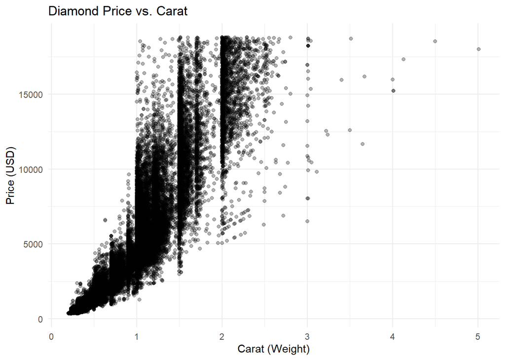

```r
# Scatterplot of price vs. carat
ggplot(data = diamonds, aes(x = carat, y = price)) +
  geom_point(alpha = 0.3) +
  labs(x = "Carat (Weight)",
       y = "Price (USD)",
       title = "Diamond Price vs. Carat") +
  theme_minimal()
```

**1.2** Now, write the R code to fit a simple linear regression model to predict `price` using `carat`. Assign the result to a variable named `fit_simple` and then use `summary()` to display the model’s results.

```r
# Fit simple linear regression model
fit_simple <- lm(price ~ carat, data = diamonds)
summary(fit_simple)
```

```
##
## Call:
## lm(formula = price ~ carat, data = diamonds)
##
## Residuals:
##      Min       1Q   Median       3Q      Max
## -18585.3   -804.8    -18.9    537.4  12731.7
##
## Coefficients:
##             Estimate Std. Error t value Pr(>|t|)
## (Intercept) -2256.36      13.06  -172.8   <2e-16 ***
## carat        7756.43      14.07   551.4   <2e-16 ***
## ---
## Signif. codes:  0 '***' 0.001 '**' 0.01 '*' 0.05 '.' 0.1 ' ' 1
##
## Residual standard error: 1549 on 53938 degrees of freedom
## Multiple R-squared:  0.8493, Adjusted R-squared:  0.8493
## F-statistic: 3.041e+05 on 1 and 53938 DF,  p-value: < 2.2e-16
```

### Part 2: Interpreting Model Output

**2.1** Using the `summary()` output from your `fit_simple` model, identify the R-squared value. In a brief paragraph, explain what this value tells you about your model’s ability to explain the variance in diamond prices.

```r
# Extract R-squared
summary(fit_simple)$r.squared
```

```
## [1] 0.8493305
```

**Explanation:** The R-squared value is approximately 0.8493, which means that about 84.93% of the variance in diamond prices can be explained by carat weight alone. This is quite high, indicating that carat is a very strong predictor of price. However, it also tells us that approximately 15% of the variation in price is due to other factors not captured by carat weight (such as cut, clarity, color, etc.).

**2.2** Locate the p-value for the `carat` coefficient in the `summary()` output. Based on this value, is `carat` a statistically significant predictor of `price`? Justify your answer using the p-value.

```r
# Extract p-value for carat coefficient
summary(fit_simple)$coefficients["carat", "Pr(>|t|)"]
```

```
## [1] 0
```

**Explanation:** The p-value for the carat coefficient is < 2.2e-16, which is essentially zero. This is far below any conventional significance level (0.05, 0.01, or 0.001). Therefore, we can confidently reject the null hypothesis that carat has no effect on price. This provides very strong statistical evidence that carat is a significant predictor of diamond price.

**2.3** Using the `confint()` function, calculate the 95% confidence interval for the model’s coefficients. In a brief paragraph, explain both the meaning of the standard error and the confidence interval for the `carat` coefficient. How are they related?

```r
# Calculate 95% confidence intervals
confint(fit_simple)
```

```
##                 2.5 %    97.5 %
## (Intercept) -2281.949 -2230.772
## carat        7728.855  7783.996
```

```r
# Standard error for carat
summary(fit_simple)$coefficients["carat", "Std. Error"]
```

```
## [1] 14.06658
```

### Part 3: Working with Multiple Predictors

**3.1** What if we want to add another predictor? Let’s add `depth` to our model. Write the R code to fit a new linear regression model (`fit_multiple`) that predicts `price` using **both** `carat` and `depth`.

```r
# Fit multiple regression model with carat and depth
fit_multiple <- lm(price ~ carat + depth, data = diamonds)
summary(fit_multiple)
```

```
##
## Call:
## lm(formula = price ~ carat + depth, data = diamonds)
##
## Residuals:
##      Min       1Q   Median       3Q      Max
## -18238.9   -801.6    -19.6    546.3  12683.7
##
## Coefficients:
##             Estimate Std. Error t value Pr(>|t|)
## (Intercept) 4045.333    286.205   14.13   <2e-16 ***
## carat       7765.141     14.009  554.28   <2e-16 ***
## depth       -102.165      4.635  -22.04   <2e-16 ***
## ---
## Signif. codes:  0 '***' 0.001 '**' 0.01 '*' 0.05 '.' 0.1 ' ' 1
##
## Residual standard error: 1542 on 53937 degrees of freedom
## Multiple R-squared:  0.8507, Adjusted R-squared:  0.8507
## F-statistic: 1.536e+05 on 2 and 53937 DF,  p-value: < 2.2e-16
```

**3.2** Use `summary()` on your new model (`fit_multiple`). Based on the output, which of the two predictors (`carat` or `depth`) is a more statistically significant predictor of `price`? Justify your answer.

```r
# Compare p-values
summary(fit_multiple)$coefficients[, "Pr(>|t|)"]
```

```
##   (Intercept)         carat         depth
##  2.809887e-45  0.000000e+00 3.486190e-107
```

**3.3** Compare the R-squared value from your simple model (`fit_simple`) with the R-squared value from your multiple model (`fit_multiple`). What does this change in R-squared tell you about the benefit of adding `depth` as a predictor?

```r
# Compare R-squared values
cat("Simple model R-squared:", summary(fit_simple)$r.squared, "\n")
```

```
## Simple model R-squared: 0.8493305
```

```r
cat("Multiple model R-squared:", summary(fit_multiple)$r.squared, "\n")
```

```
## Multiple model R-squared: 0.8506755
```

```r
cat("Difference:", summary(fit_multiple)$r.squared - summary(fit_simple)$r.squared, "\n")
```

```
## Difference: 0.001344931
```

### Part 4: Model Diagnostics and Prediction

**4.1** One of the key assumptions of linear regression is **linearity**, meaning the relationship between the predictors and the response is linear. We can check this by plotting the residuals against the fitted values.

Write the R code to create this diagnostic plot for your `fit_multiple` model. Use a scatterplot with fitted values on the x-axis and residuals on the y-axis. Do you think the **linearity** assumption holds here?

**Hints:**

- A good plot for a linear model should show a random scatter of points around the horizontal line at $y=0$. Patterns such as a U-shape, a curve, or a fan-like spread would suggest that the linearity assumption has been violated.
- To get fitted values from your model, use the `fitted()` function: `fitted(fit_multiple)`
- To get residuals from your model, use the `resid()` function: `resid(fit_multiple)`
- In your `ggplot()`, map the fitted values to the x-axis and residuals to the y-axis
- Consider adding `geom_hline(yintercept = 0, linetype = "dashed", color = "red")` to show the zero line clearly

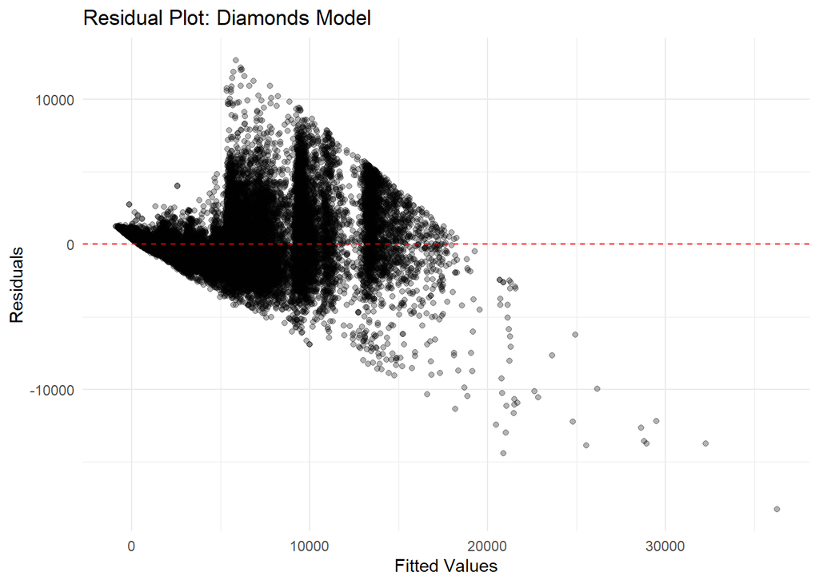

```r
# Create residual plot for diamonds model
residual_data <- data.frame(
  fitted = fitted(fit_multiple),
  residuals = resid(fit_multiple)
)

ggplot(residual_data, aes(x = fitted, y = residuals)) +
  geom_point(alpha = 0.3) +
  geom_hline(yintercept = 0, linetype = "dashed", color = "red") +
  labs(x = "Fitted Values",
       y = "Residuals",
       title = "Residual Plot: Diamonds Model") +
  theme_minimal()
```

**Comparison: What a GOOD residual plot looks like**

Let’s create a simple example with data that truly follows a linear relationship:

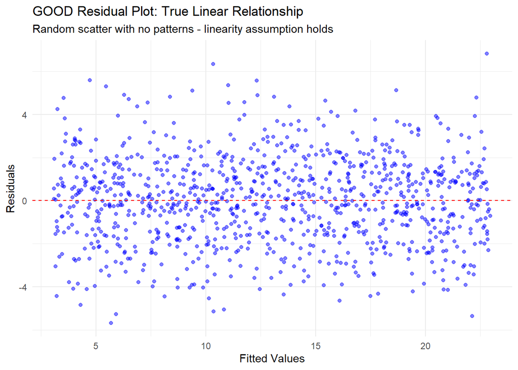

```r
# Generate data with a true linear relationship
set.seed(123)
n <- 1000
x_linear <- runif(n, 0, 10)
y_linear <- 3 + 2*x_linear + rnorm(n, 0, 2)  # True linear model with normal errors

# Fit model
fit_linear_example <- lm(y_linear ~ x_linear)

# Create residual plot
residual_data_good <- data.frame(
  fitted = fitted(fit_linear_example),
  residuals = resid(fit_linear_example)
)

ggplot(residual_data_good, aes(x = fitted, y = residuals)) +
  geom_point(alpha = 0.5, color = "blue") +
  geom_hline(yintercept = 0, linetype = "dashed", color = "red") +
  labs(x = "Fitted Values",
       y = "Residuals",
       title = "GOOD Residual Plot: True Linear Relationship",
       subtitle = "Random scatter with no patterns - linearity assumption holds") +
  theme_minimal()
```

**Assessment of Diamonds Model:**

The residual plot for the diamonds model shows clear violations of the linearity assumption:

1. **Fan shape (heteroscedasticity):** The spread of residuals increases dramatically as fitted values increase, creating a cone or fan pattern. This violates the assumption of constant variance.
2. **Non-random pattern:** The residuals are not randomly scattered around zero. There appears to be structure in the residuals, suggesting the linear model is not capturing the true relationship.
3. **Curvature:** There may be subtle curvature in the residual pattern, particularly at higher fitted values.

In contrast, the “good” example shows residuals randomly scattered around zero with relatively constant variance across all fitted values - exactly what we want to see.

The diamonds data likely needs transformation (such as log transformation) or a more complex model to better satisfy the linearity assumption.

**4.2** Using your `fit_multiple` model, predict the price for a new diamond with a `carat` of **1.5** and a `depth` of **60**. You’ll need to create a new `data.frame` for the `predict()` function.

```r
# Create new data for prediction
new_diamond <- data.frame(carat = 1.5, depth = 60)

# Predict price
predicted_price <- predict(fit_multiple, newdata = new_diamond)
cat("Predicted price for a 1.5 carat diamond with depth 60:",
    round(predicted_price, 2), "USD\n")
```

```
## Predicted price for a 1.5 carat diamond with depth 60: 9563.12 USD
```

### Part 5: Challenge Task

Using your simple linear model (`fit_simple`), plot the original scatterplot again. This time, add the line of best fit to the plot using `geom_smooth()` with `method = "lm"`. Additionally, add a segment for each point showing its residual (the vertical distance from the point to the line).

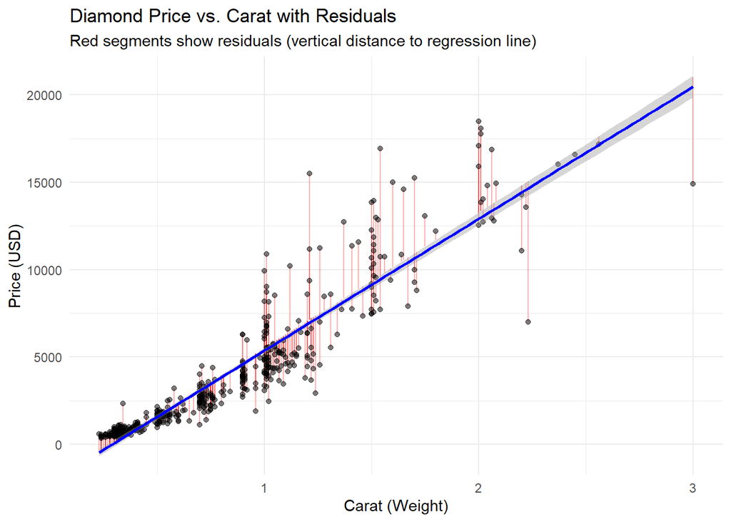

```r
# Create data frame with fitted values and residuals
diamonds_with_fit <- diamonds
diamonds_with_fit$fitted_values <- fitted(fit_simple)
diamonds_with_fit$residuals <- resid(fit_simple)

# Sample 500 points for clarity (optional - remove if you want all points)
set.seed(42)
diamonds_sample <- diamonds_with_fit[sample(nrow(diamonds_with_fit), 500), ]

# Plot with residual segments
ggplot(diamonds_sample, aes(x = carat, y = price)) +
  geom_segment(aes(xend = carat, yend = fitted_values),
               alpha = 0.3, color = "red") +
  geom_point(alpha = 0.5) +
  geom_smooth(method = "lm", se = TRUE, color = "blue", linewidth = 1) +
  labs(x = "Carat (Weight)",
       y = "Price (USD)",
       title = "Diamond Price vs. Carat with Residuals",
       subtitle = "Red segments show residuals (vertical distance to regression line)") +
  theme_minimal()
```

### Activity Wrap-up

Once you have completed all the tasks and the code runs without errors, you’ve successfully worked through the major practical components of linear regression. Feel free to re-run any code chunks to check your work.

### Part 6: Bonus Tasks

**Bonus 1: Categorical Predictors**

The `diamonds` dataset also includes categorical variables like `cut`, which has levels: Fair, Good, Very Good, Premium, and Ideal. Fit a new linear regression model (`fit_categorical`) that predicts `price` using `carat` and `cut`.

```r
# Fit model with categorical predictor
fit_categorical <- lm(price ~ carat + cut, data = diamonds)
summary(fit_categorical)
```

```
##
## Call:
## lm(formula = price ~ carat + cut, data = diamonds)
##
## Residuals:
##      Min       1Q   Median       3Q      Max
## -17540.7   -791.6    -37.6    522.1  12721.4
##
## Coefficients:
##             Estimate Std. Error  t value Pr(>|t|)
## (Intercept) -2701.38      15.43 -175.061  < 2e-16 ***
## carat        7871.08      13.98  563.040  < 2e-16 ***
## cut.L        1239.80      26.10   47.502  < 2e-16 ***
## cut.Q        -528.60      23.13  -22.851  < 2e-16 ***
## cut.C         367.91      20.21   18.201  < 2e-16 ***
## cut^4          74.59      16.24    4.593 4.37e-06 ***
## ---
## Signif. codes:  0 '***' 0.001 '**' 0.01 '*' 0.05 '.' 0.1 ' ' 1
##
## Residual standard error: 1511 on 53934 degrees of freedom
## Multiple R-squared:  0.8565, Adjusted R-squared:  0.8565
## F-statistic: 6.437e+04 on 5 and 53934 DF,  p-value: < 2.2e-16
```

```r
# Check the levels of cut
levels(diamonds$cut)
```

```
## [1] "Fair"      "Good"      "Very Good" "Premium"   "Ideal"
```

**Explanation:** R handles categorical variables by creating dummy variables (also called indicator variables). For a categorical variable with k levels, R creates k-1 dummy variables.

Interestingly, some of the cut coefficients are negative, which seems counterintuitive - this is because carat and cut are correlated, and larger diamonds tend to have lower quality cuts.

**Bonus 2: Interaction Effects**

Perhaps the effect of `carat` on `price` differs depending on the diamond’s `cut` quality. Fit a model (`fit_interaction`) that includes an interaction between `carat` and `cut`. Compare the R-squared of this model to your previous models.

```r
# Fit model with interaction terms
fit_interaction <- lm(price ~ carat * cut, data = diamonds)
summary(fit_interaction)
```

```
##
## Call:
## lm(formula = price ~ carat * cut, data = diamonds)
##
## Residuals:
##      Min       1Q   Median       3Q      Max
## -14878.3   -793.0    -23.0    546.3  12706.2
##
## Coefficients:
##             Estimate Std. Error  t value Pr(>|t|)
## (Intercept) -2271.95      20.94 -108.513  < 2e-16 ***
## carat        7468.05      19.49  383.200  < 2e-16 ***
## cut.L        -278.21      57.17   -4.866 1.14e-06 ***
## cut.Q         363.22      50.51    7.191 6.50e-13 ***
## cut.C        -172.96      42.81   -4.041 5.34e-05 ***
## cut^4          67.55      33.40    2.022   0.0431 *
## carat:cut.L  1538.10      50.96   30.183  < 2e-16 ***
## carat:cut.Q  -781.89      45.89  -17.037  < 2e-16 ***
## carat:cut.C   509.65      41.36   12.321  < 2e-16 ***
## carat:cut^4    69.70      34.38    2.027   0.0426 *
## ---
## Signif. codes:  0 '***' 0.001 '**' 0.01 '*' 0.05 '.' 0.1 ' ' 1
##
## Residual standard error: 1498 on 53930 degrees of freedom
## Multiple R-squared:  0.8591, Adjusted R-squared:  0.859
## F-statistic: 3.653e+04 on 9 and 53930 DF,  p-value: < 2.2e-16
```

```r
# Compare R-squared values
cat("\nR-squared comparison:\n")
```

```
##
## R-squared comparison:
```

```r
cat("Simple model (carat only):", summary(fit_simple)$r.squared, "\n")
```

```
## Simple model (carat only): 0.8493305
```

```r
cat("Multiple model (carat + depth):", summary(fit_multiple)$r.squared, "\n")
```

```
## Multiple model (carat + depth): 0.8506755
```

```r
cat("Categorical model (carat + cut):", summary(fit_categorical)$r.squared, "\n")
```

```
## Categorical model (carat + cut): 0.8564748
```

```r
cat("Interaction model (carat * cut):", summary(fit_interaction)$r.squared, "\n")
```

```
## Interaction model (carat * cut): 0.8590645
```

The interaction terms allow different slopes for the carat-price relationship for each cut level. This makes intuitive sense: the premium for additional carat weight might be higher for better cut diamonds. The significant interaction terms indicate that carat and cut jointly affect price in a way that cannot be captured by simply adding their individual effects.

**Bonus 3: Residual Diagnostics**

Create a Q-Q plot (quantile-quantile plot) of the residuals from your `fit_multiple` model to assess the **normality assumption** of linear regression. The residuals should approximately follow a normal distribution.

A Q-Q plot compares the quantiles of your residuals to the quantiles of a theoretical normal distribution. If the residuals are normally distributed, the points should fall approximately along a straight diagonal line. Departures from this line indicate departures from normality: points curving above the line suggest heavy tails, while points curving below suggest light tails.

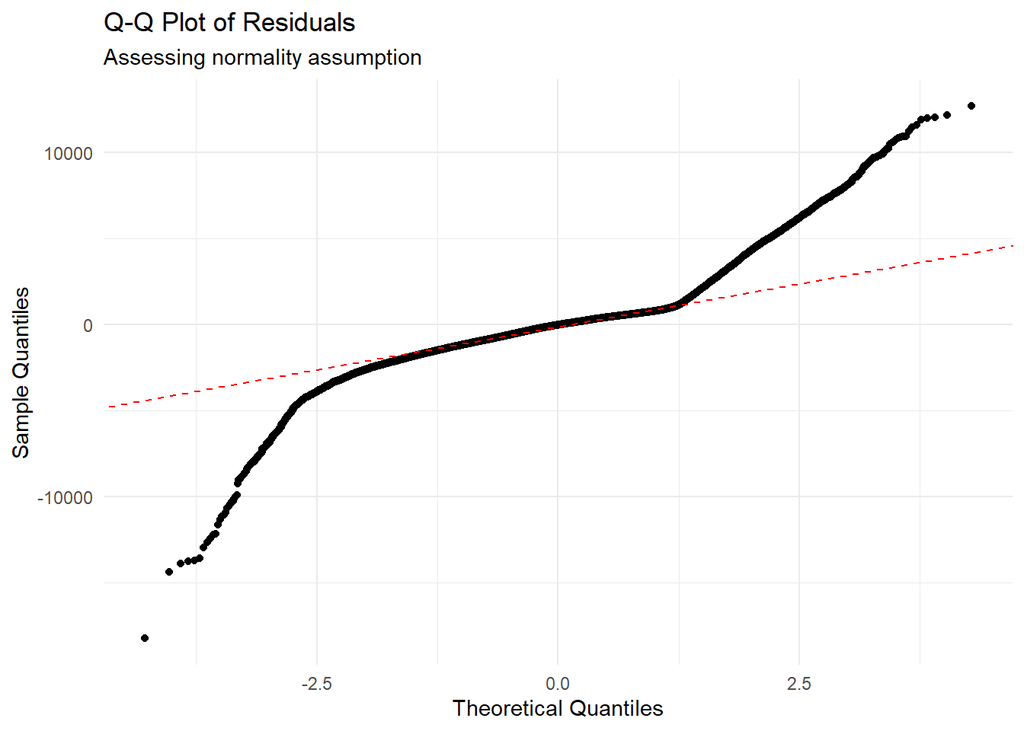

```r
# Create Q-Q plot of residuals
ggplot(data.frame(residuals = resid(fit_multiple)), aes(sample = residuals)) +
  stat_qq() +
  stat_qq_line(color = "red", linetype = "dashed") +
  labs(title = "Q-Q Plot of Residuals",
       subtitle = "Assessing normality assumption",
       x = "Theoretical Quantiles",
       y = "Sample Quantiles") +
  theme_minimal()
```

These departures from normality suggest that inference (confidence intervals, p-values) may be somewhat unreliable, though with large sample sizes, the central limit theorem provides some protection. The patterns reinforce our earlier finding that the model specification may not be ideal for this data.

**Bonus 4: Log Transformation**

Both `price` and `carat` are highly right-skewed. Fit a new model (`fit_log`) that predicts `log(price)` using `log(carat)`. Compare the residual plot and R-squared to your original `fit_simple` model.

```r
# Fit log-transformed model
fit_log <- lm(log(price) ~ log(carat), data = diamonds)
summary(fit_log)
```

```
##
## Call:
## lm(formula = log(price) ~ log(carat), data = diamonds)
##
## Residuals:
##      Min       1Q   Median       3Q      Max
## -1.50833 -0.16951 -0.00591  0.16637  1.33793
##
## Coefficients:
##             Estimate Std. Error t value Pr(>|t|)
## (Intercept) 8.448661   0.001365  6190.9   <2e-16 ***
## log(carat)  1.675817   0.001934   866.6   <2e-16 ***
## ---
## Signif. codes:  0 '***' 0.001 '**' 0.01 '*' 0.05 '.' 0.1 ' ' 1
##
## Residual standard error: 0.2627 on 53938 degrees of freedom
## Multiple R-squared:  0.933,  Adjusted R-squared:  0.933
## F-statistic: 7.51e+05 on 1 and 53938 DF,  p-value: < 2.2e-16
```

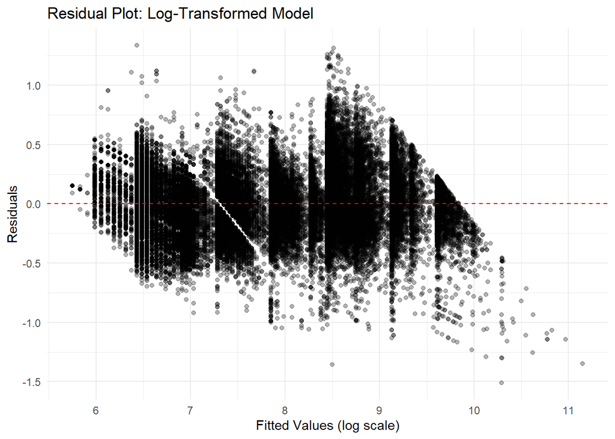

```r
# Create residual plot for log model
residual_data_log <- data.frame(
  fitted = fitted(fit_log),
  residuals = resid(fit_log)
)

ggplot(residual_data_log, aes(x = fitted, y = residuals)) +
  geom_point(alpha = 0.3) +
  geom_hline(yintercept = 0, linetype = "dashed", color = "red") +
  labs(x = "Fitted Values (log scale)",
       y = "Residuals",
       title = "Residual Plot: Log-Transformed Model") +
  theme_minimal()
```

```r
# Compare R-squared
cat("\nR-squared comparison:\n")
```

```
##
## R-squared comparison:
```

```r
cat("Original model:", summary(fit_simple)$r.squared, "\n")
```

```
## Original model: 0.8493305
```

```r
cat("Log-transformed model:", summary(fit_log)$r.squared, "\n")
```

```
## Log-transformed model: 0.9329893
```

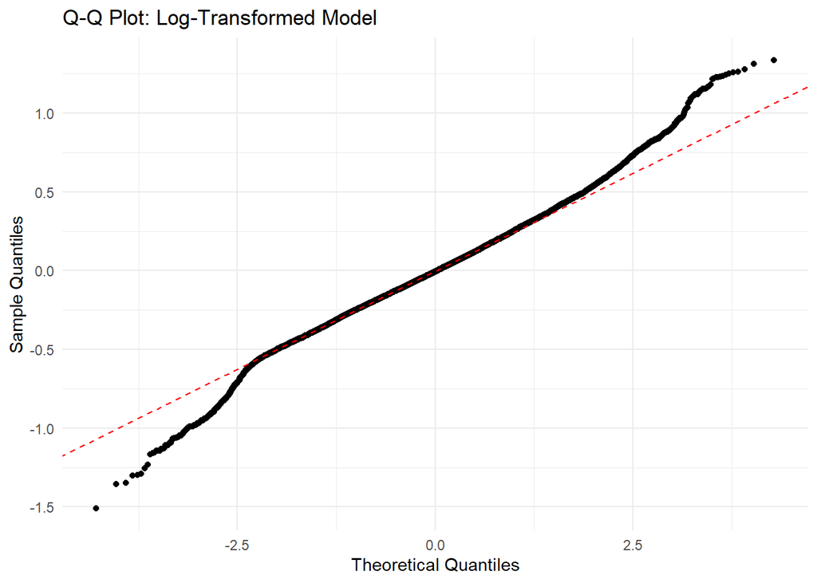

```r
# Q-Q plot for log model
ggplot(data.frame(residuals = resid(fit_log)), aes(sample = residuals)) +
  stat_qq() +
  stat_qq_line(color = "red", linetype = "dashed") +
  labs(title = "Q-Q Plot: Log-Transformed Model",
       x = "Theoretical Quantiles",
       y = "Sample Quantiles") +
  theme_minimal()
```

**Assessment:** The log transformation provides substantial improvements:

1. **Better residual plot:** The fan shape (heteroscedasticity) is greatly reduced. The residuals show much more constant variance across fitted values, though some patterns remain.
2. **Improved normality:** The Q-Q plot is much closer to the diagonal line, indicating residuals are more normally distributed.
3. **Higher R-squared:** The R-squared increases to approximately 0.933, explaining about 9 percentage points more variance than the untransformed model.

**Interpretation of log-log model:** In a log-log model, the coefficient on `log(carat)` represents an elasticity. The coefficient of approximately 1.68 means that a 1% increase in carat is associated with approximately a 1.68% increase in price. This is an economically meaningful interpretation - the relationship is more than proportional, indicating that larger diamonds command a premium beyond their weight.

The log transformation is clearly superior for this data, addressing multiple assumption violations and improving model fit.